# Coursework Report

*N* removed NAs: 3

*N* removed typo: 1

*N* removed <18: 33

*N* total clean: 113

| Group | *N* | *M*<sub>age</sub> | *M*<sub>rating</sub> |
| --- | --- | --- | --- |
| Control | 60 | 20.68 | 5.93 |
| Experim | 53 | 20.72 | 7.58 |

**Main analysis results**

*t*(111) = -11.22, *p* < .001

[interactive chart not shown]

[figure not shown]

[interactive chart not shown]

# Coursework Report

Analysing Data, Spring 2020

# Methods

## Participants

In this study there was originally 150 participants who took part however, some participants were removed from the dataset. In order to adhere to ethical guidelines, it was decided that those under 18 years old should not be included. Therefore, 33 participants were removed from the dataset as a result of being under 18 and 4 participants were removed for not inputting their ages as there is no way to guarantee they were over 18. This leaves us with 113 participants (*M*<sub>age</sub> = 20.68, 20.72, *SD*<sub>age</sub> = 2.17, 1.74, range = 18, 18 - 28, 25) for analysis.

*Table 1* Descriptive Statistics of Age by Condition

| Condition | *M*<sub>age</sub> | *SD*<sub>age</sub> | Minimum age | Maximum age |
| --- | --- | --- | --- | --- |
| White | 20.68 | 2.17 | 18 | 28 |
| Red | 20.72 | 1.74 | 18 | 25 |

## Design

This study aimed to replicated Elliot et al.’s (2010) experiment one in *Red, Rank and Romance in Viewing Men* which appeared to show there was a red effect whereby women found men more attractive when they were presented with the colour red than when they were presented with just white. This study therefore aimed to explore the question does the red effect actually exist?

The independent variable for this study was the background colour of the photo of the man, measured as a factor which had two levels: red or white. The dependent variable for this study was the attractiveness score the participants gave for the man which was measured as a rating. When asked three questions about the man’s attractiveness, they gave a score from 1 to 9 with 1 being not at all attractive and 9 being extremely attractive and then the scores were averaged forming a composite score.

It is hypothesised that the photo of the man with the red background will be given a higher attractiveness score by participants than the photo of the man with the white background. In order to test this hypothesis I will conduct a two-tailed t-test.

# Results

This study aimed to find out if there was a red effect when participants rated attractiveness of a man. When we had gathered the 3 scores from each participant, a composite score was created. This was calculated by finding the mean of the 3 ratings given by the participants. Then, we found a mean of all of these composite scores for each condition in order to compare them.

Figure 1 shows the differences between the means of the attractiveness scores by colour condition. The mean was higher for the red condition (*M* = 7.58) compared to the white condition (*M* = 5.93) showing that the colour red may have more of an impact on attractiveness than white. The standard deviation for the red condition (*SD* = 0.71) was less than the white condition (*SD* = 0.83) meaning that the data was less spread for the red condition.

We then conducted an independent measures t-test in order to determine the significance of the results. There was a significant difference in the attractiveness scores in the different colour conditions (*M*<sub>diff</sub> = 1.65, 95% CI [-1.36, -1.94], *t* (111) = -11.22, *p* = < .001). This indicates that we would be unlikely to obtain this difference in means if the null hypothesis was correct.

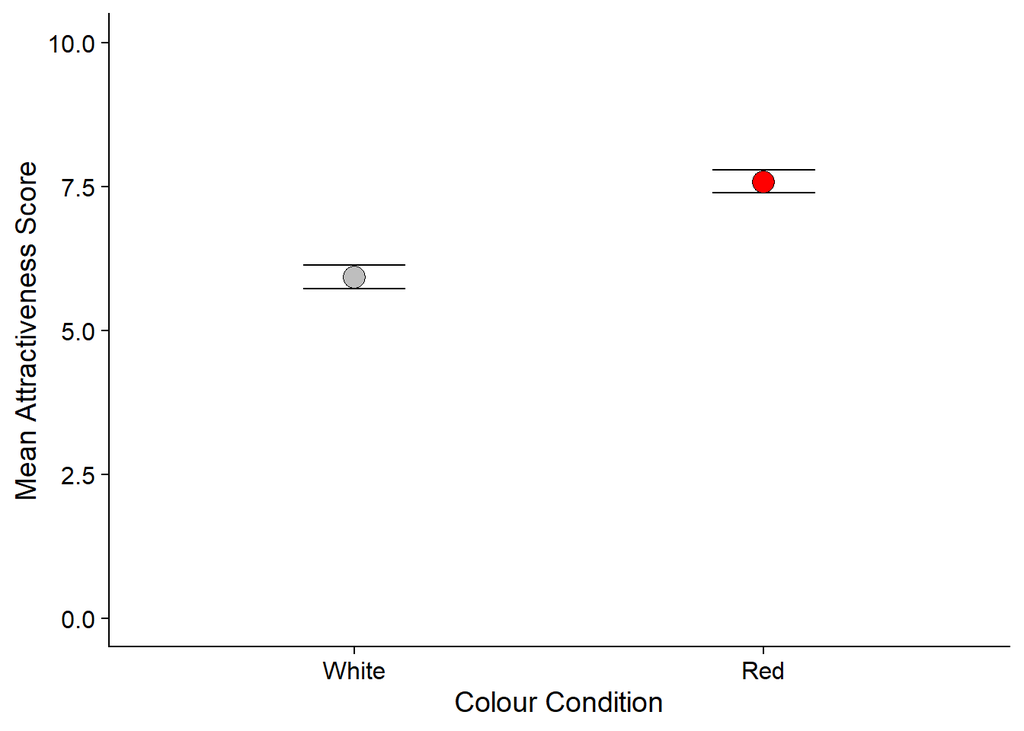

*Figure 1.* Mean Attractiveness Score by Colour Condition

# Discussion

This study aimed to investigate if the red effect shown by Elliot et al. (2010) actually exists. The statistical analysis of our results has shown that there does appear to be a red effect as it is unlikely to have obtained these results unless the colour condition did indeed have an effect on the attractiveness score. This therefore provides support that the Elliot et al.’s (2010) red effect exists.

When thinking about the wider research area the results of this study show an interesting perspective on the idea of the red effect. Many studies have failed to replicate the same pattern of results as Elliot et al.’s (2010) study. One example is Hessinger et al.’s (2015) study where they closely replicated Elliot et al.’s (2010) study and despite having a larger sample they were not able to find evidence of a red affect occurring. Hazan and Briggs (2016) also attempted a replication however they were also not able to show the results that Elliot et al. (2010) found. This does create some issues as we are unable to determine the cause of the difference in results.

There have however been other studies that have been able to show some evidence for this red effect existing. Roberts et al. (2010) conducted a study in which participants were shown pictures of the opposite sex wearing six different coloured t-shirts and were asked to rate their attractiveness. For females rating males, the pictures of the men wearing red t-shirts received the highest score on average. Whilst there wasn’t a significant difference between the colour red and black, there was a significant difference between red and the other 4 colours (blue, green, yellow and white). This study shows the same pattern of results as our study. This is interesting for our study because Robert’s et al. (2010) is slightly more ecologically valid as rather than the picture being simply presented with a coloured frame as in our study, their study actually showed pictures of people wearing the colours which is more realistic to how people are going to be perceived in real life. Exploring this idea of ecological validity may be important for showing the red effect. Gueguen (2010) did a study where women confederates posed as hitchhikers and wore different coloured t-shirts to see what would be the most likely to be picked up by the opposite sex. They found that this was most likely to happen when the confederate was wearing a red t-shirt compared other colours. This study also shows the same pattern of results as our study as it shows there is a red effect not just for women finding men attractive but for men finding women attractive also. There have therefore been both studies which support the results of our study as well as those which seem to dispute our results.

Our study is good for showing that there may be a red effect in women finding men attractive as we were able to show statistical significance for our results. This study also had a relatively big sample size so it shows a higher significance level. This study used an independent measures design which is a strength as the participants would’ve been less likely to guess the aim of the study and therefore would’ve affected validity as they may have tried to act differently. However there are some limitations. The oldest participant in this study was only 28 so we are unable to comment if this red effect occurs for all women or if there may be a difference for the red effect occurring in women of different ages. This may be a possible topic for future research. We are also unable to comment on if this red effect occurs in men finding women attractive. Whilst there has been research to suggest this may exist (Gueguen 2010), our study is unable to show this as we only looked at the red effect in relation to women finding men attractive as per Elliot et al.’s (2010) study.

Further research in this area may apply to looking at factors which affect the red effect. For example looking at if age has an impact on if the red effect may occur for different people. It may also be interesting to explore a more ecological route like Gueguen (2010) looked at. To show the red effect truly exists it needs to be shown that it can exist outside of the confines of a lab study. Whilst there has been research into looking at the red effect in opposite sex attraction, there has been little research conducted towards if this occurs in people who experience same sex attraction. This may also be an interesting route to take for further research in this area.

In conclusion, this study has successfully replicated Elliot et al.’s (2010) study with a large sample and found that there is a red effect may exist for women finding men attractive which has been statistically shown with the use of an independent t-test.

# References

Elliot, A. J., Niesta Kayser, D., Greitemeyer, T., Lichtenfeld, S., Gramzow, R. H., Maier, M. A., & Liu, H. (2010). Red, rank, and romance in women viewing men. Journal of Experimental Psychology: General, 139(3), 399–417. doi.org/10.1037/a0019689

Gueguen, Nicolas. (2010). Color and women hitchhikers’ attractiveness: Gentlemen drivers prefer red. Color Research and Application, 37(1), 76–78. doi.org/10.1080/00224545.2011.605398

Haran, K., & Briggs, S. G. (2016). Red, Rank, and Romance in Women Viewing Men A Replication Study. 21. Retrieved from https://escholarship.org/uc/item/5b60s9dw

Hesslinger, V. M., Goldbach, L., & Carbon, C.-C. (2015). Men in red: A reexamination of the red-attractiveness effect. Psychon Bull Rev, 7. doi.org/10.3758/s13423-015-0866-8

Roberts, S. C., Owen, R. C., & Havlicek, J. (2010). Distinguishing between Perceiver and Wearer Effects in Clothing Color-Associated Attributions. Evolutionary Psychology, 8, 15. doi.org/10.1027/1864-9335/a000296